# Projeto de Capacidade Produtiva - Fase II

Allan B. Martins

31 maio 2022

# 1 Técnica utilizada para criação dos Modelos de Análise Envoltória de Dados (DEA) **2021** - **JAN A DEZ** - **DEA - Variável ‘INFRA’** - (**v6**)

Contextualização

A Metodologia DEA (Data Envelopment Analysis)

O primeiro modelo DEA foi proposto por Charnes, Coooper e Rhodes (1978) que, a seu tributo, se designou DEA – CCR, tinha orientação ao input e pressupunha a existência de retornos constantes de escala (CRS). Esta metodologia procura estabelecer quais as empresas, de uma dada amostra, determinam a superfície envolvente ou fronteira de produção eficiente.

A metodologia DEA é aplicada na avaliação unitária de unidades homogéneas ou empresas, tais como hotéis. A unidade em avaliação é normalmente denominada como uma unidade de tomada de decisão (DMU, Data Managment Unit) que converte inputs em outputs, facto pelo qual em qualquer estudo a sua identificação é um aspeto difícil e crucial. Segundo DEA, o desempenho de uma empresa é avaliado em relação a uma fronteira eficiente, que é construída através da combinação linear das empresas existentes. O procedimento baseia-se numa formulação matemática sofisticada.

Usaremos a função “deaR” desse pacote e seus padrões (default), com seu conjunto de funções para Análise de Envoltório de Dados. Ele executa modelos DEA clássicos e difusos

# 2 Etapa I - Estruturação do banco de dados e criação da variável “INFRA” baseada na aplicação dos pesos adiquiridos do PCA

## 2.1 Tabela de dados completa Original

Tabela de dados completa original

| uf | zy_ubp_1000_hab | rec_gerad_2021 | zy_custo_ubp_n | zf_custeio_t | zf_ftp | zs_energ | zs_transp | zs_telecom | zs_snb | zs_econ | zs_seg_nub_n | zs_geo_n | zs_estaber_capta |
| --- | --- | --- | --- | --- | --- | --- | --- | --- | --- | --- | --- | --- | --- |
| AC | 1.4813 | 0.1650 | 82.05 | 0.4746 | 0.0000 | 0.0000 | 15.511 | 18.242 | 9.025 | 0.000 | 99.31 | 0.00 | 12.601 |
| AL | 9.4578 | 2.4503 | 91.79 | 1.6083 | 8.4109 | 56.7958 | 73.091 | 7.090 | 26.675 | 9.556 | 97.44 | 100.00 | 20.482 |
| AM | 7.7310 | 5.0086 | 48.37 | 4.7446 | 7.4505 | 0.2062 | 0.000 | 6.325 | 4.854 | 76.793 | 96.26 | 71.35 | 4.426 |
| AP | 0.0000 | 0.0000 | 44.09 | 0.4693 | 0.1164 | 1.9806 | 6.511 | 29.506 | 34.163 | 7.308 | 100.00 | 47.24 | 8.129 |
| BA | 23.3299 | 15.1746 | 52.38 | 12.5812 | 34.1094 | 8.0263 | 25.621 | 25.380 | 58.319 | 31.046 | 82.73 | 100.00 | 40.649 |
| CE | 12.0467 | 11.0371 | 23.88 | 10.0357 | 19.7905 | 10.0243 | 35.938 | 16.174 | 61.070 | 18.124 | 88.04 | 100.00 | 39.619 |
| ES | 8.7838 | 7.0911 | 27.02 | 7.2210 | 4.7730 | 16.1815 | 48.596 | 28.747 | 97.299 | 73.581 | 90.75 | 100.00 | 83.550 |
| GO | 6.7567 | 6.3966 | 42.92 | 4.5840 | 15.7159 | 10.9773 | 23.810 | 11.574 | 30.911 | 42.072 | 88.01 | 100.00 | 72.085 |
| MA | 7.4048 | 5.1024 | 52.69 | 4.2341 | 7.2759 | 3.6247 | 21.259 | 20.788 | 0.000 | 11.061 | 93.28 | 100.00 | 0.000 |
| MG | 47.1933 | 31.8963 | 62.56 | 20.6580 | 21.3038 | 13.1168 | 31.436 | 12.654 | 92.467 | 71.831 | 83.76 | 100.00 | 72.121 |
| MS | 9.3221 | 8.2386 | 13.36 | 8.8980 | 6.4028 | 5.3319 | 23.867 | 39.037 | 65.331 | 71.226 | 96.53 | 48.41 | 67.726 |
| MT | 18.1429 | 12.4704 | 65.84 | 7.5533 | 9.8079 | 1.0611 | 9.818 | 29.331 | 22.303 | 54.348 | 96.29 | 82.92 | 80.901 |
| PA | 9.9726 | 7.4753 | 76.03 | 3.2569 | 5.0058 | 4.6354 | 4.026 | 54.480 | 1.244 | 60.860 | 91.84 | 94.22 | 7.894 |
| PB | 17.9712 | 4.7456 | 97.79 | 2.0351 | 5.5879 | 4.8479 | 51.469 | 3.185 | 68.351 | 13.915 | 97.69 | 100.00 | 34.331 |
| PE | 14.9574 | 11.6211 | 47.65 | 8.8842 | 7.8871 | 17.5951 | 53.448 | 5.990 | 78.932 | 27.549 | 84.21 | 100.00 | 21.627 |
| PI | 3.6196 | 3.6728 | 29.84 | 3.2318 | 6.6647 | 2.0164 | 22.906 | 6.481 | 4.536 | 7.853 | 94.70 | 100.00 | 37.797 |
| PR | 27.4771 | 24.8506 | 30.16 | 20.4269 | 22.5844 | 39.7485 | 44.658 | 11.838 | 50.366 | 93.790 | 83.49 | 66.68 | 94.191 |
| RJ | 34.3880 | 29.5179 | 31.83 | 24.8804 | 42.3749 | 100.0000 | 100.000 | 70.511 | 94.275 | 98.296 | 61.58 | 100.00 | 59.530 |
| RN | 4.1030 | 3.0067 | 43.79 | 2.9318 | 7.4505 | 24.8057 | 65.316 | 0.000 | 40.707 | 25.765 | 95.81 | 100.00 | 34.061 |
| RO | 3.6093 | 3.2120 | 86.86 | 0.8197 | 3.2596 | 9.2993 | 17.106 | 9.361 | 2.763 | 31.726 | 97.13 | 43.60 | 37.820 |
| RR | 0.8699 | 0.1189 | 100.00 | 0.0000 | 1.5134 | 0.3791 | 10.569 | 6.653 | 29.773 | 4.946 | 99.54 | 10.29 | 14.545 |
| RS | 15.9710 | 18.0689 | 58.22 | 7.8429 | 12.2235 | 14.1762 | 45.727 | 24.786 | 28.148 | 83.959 | 85.09 | 51.16 | 87.927 |
| SC | 27.1745 | 17.7818 | 63.56 | 11.7627 | 19.2084 | 25.7655 | 56.729 | 17.269 | 36.439 | 100.000 | 92.19 | 76.93 | 100.000 |
| SE | 6.4598 | 2.2165 | 69.99 | 2.5723 | 6.1409 | 72.4907 | 32.528 | 48.932 | 41.010 | 26.456 | 97.77 | 100.00 | 16.726 |
| SP | 100.0000 | 100.0000 | 0.00 | 100.0000 | 100.0000 | 44.4685 | 9.792 | 100.000 | 100.000 | 87.553 | 0.00 | 100.00 | 78.620 |
| TO | 2.6785 | 1.6498 | 49.58 | 1.8821 | 6.0536 | 2.9739 | 14.381 | 11.585 | 8.301 | 17.730 | 98.84 | 100.00 | 52.282 |

## 2.2 Tabela com resultados dos pesos das variáveis estruturantes para criação da variável “INFRA”

Tabela com resultados dos pesos das variáveis estruturantes para criação da variável ‘INFRA’

| var_estruturantes | Dim1 | Dim2 | Dim3 | SomaDim13 | percentDim13 |
| --- | --- | --- | --- | --- | --- |
| zs_estaber_capta | 10.9 | 1.55 | 42.36 | 55 | 18.27% |
| zs_transp | 8.1 | 41.05 | 1.44 | 51 | 16.85% |
| zs_telecom | 12.7 | 16.99 | 17.62 | 47 | 15.78% |
| zs_econ | 14.9 | 5.62 | 17.28 | 38 | 12.60% |
| zs_seg_nub_n | 16.3 | 12.10 | 7.64 | 36 | 12.00% |
| zs_energ | 14.8 | 9.46 | 7.89 | 32 | 10.71% |
| zs_geo_n | 5.6 | 12.45 | 5.62 | 24 | 7.89% |
| zs_snb | 16.8 | 0.78 | 0.15 | 18 | 5.90% |

## 2.3 Tabela com dados tratado com pesos nas variáveis estruturantes para criação da variável “INFRA”

Tabela com dados tratado com pesos nas variáveis estruturantes para criação da variável ‘INFRA’

| uf | zy_ubp_1000_hab | rec_gerad_2021 | zy_custo_ubp_n | zf_custeio_t | zf_ftp | zs_estaber_capta | zs_transp | zs_telecom | zs_econ | zs_seg_nub_n | zs_energ | zs_geo_n | zs_snb |
| --- | --- | --- | --- | --- | --- | --- | --- | --- | --- | --- | --- | --- | --- |
| AC | 1.4813 | 0.1650 | 82.05 | 0.4746 | 0.0000 | 2.3021 | 2.6137 | 2.8786 | 0.0000 | 11.917 | 0.0000 | 0.0000 | 0.5325 |
| AL | 9.4578 | 2.4503 | 91.79 | 1.6083 | 8.4109 | 3.7420 | 12.3158 | 1.1188 | 1.2040 | 11.693 | 6.0828 | 7.8900 | 1.5738 |
| AM | 7.7310 | 5.0086 | 48.37 | 4.7446 | 7.4505 | 0.8087 | 0.0000 | 0.9981 | 9.6759 | 11.551 | 0.0221 | 5.6297 | 0.2864 |
| AP | 0.0000 | 0.0000 | 44.09 | 0.4693 | 0.1164 | 1.4851 | 1.0971 | 4.6561 | 0.9208 | 12.000 | 0.2121 | 3.7272 | 2.0156 |
| BA | 23.3299 | 15.1746 | 52.38 | 12.5812 | 34.1094 | 7.4265 | 4.3171 | 4.0049 | 3.9118 | 9.927 | 0.8596 | 7.8900 | 3.4408 |
| CE | 12.0467 | 11.0371 | 23.88 | 10.0357 | 19.7905 | 7.2383 | 6.0555 | 2.5523 | 2.2836 | 10.564 | 1.0736 | 7.8900 | 3.6031 |
| ES | 8.7838 | 7.0911 | 27.02 | 7.2210 | 4.7730 | 15.2647 | 8.1885 | 4.5362 | 9.2711 | 10.890 | 1.7330 | 7.8900 | 5.7406 |
| GO | 6.7567 | 6.3966 | 42.92 | 4.5840 | 15.7159 | 13.1698 | 4.0120 | 1.8264 | 5.3011 | 10.561 | 1.1757 | 7.8900 | 1.8237 |
| MA | 7.4048 | 5.1024 | 52.69 | 4.2341 | 7.2759 | 0.0000 | 3.5821 | 3.2803 | 1.3937 | 11.194 | 0.3882 | 7.8900 | 0.0000 |
| MG | 47.1933 | 31.8963 | 62.56 | 20.6580 | 21.3038 | 13.1765 | 5.2969 | 1.9968 | 9.0507 | 10.052 | 1.4048 | 7.8900 | 5.4555 |
| MS | 9.3221 | 8.2386 | 13.36 | 8.8980 | 6.4028 | 12.3736 | 4.0216 | 6.1600 | 8.9745 | 11.584 | 0.5710 | 3.8193 | 3.8545 |
| MT | 18.1429 | 12.4704 | 65.84 | 7.5533 | 9.8079 | 14.7807 | 1.6544 | 4.6284 | 6.8478 | 11.555 | 0.1136 | 6.5420 | 1.3159 |
| PA | 9.9726 | 7.4753 | 76.03 | 3.2569 | 5.0058 | 1.4422 | 0.6784 | 8.5970 | 7.6684 | 11.021 | 0.4965 | 7.4338 | 0.0734 |
| PB | 17.9712 | 4.7456 | 97.79 | 2.0351 | 5.5879 | 6.2723 | 8.6725 | 0.5026 | 1.7533 | 11.723 | 0.5192 | 7.8900 | 4.0327 |
| PE | 14.9574 | 11.6211 | 47.65 | 8.8842 | 7.8871 | 3.9512 | 9.0060 | 0.9452 | 3.4711 | 10.105 | 1.8844 | 7.8900 | 4.6570 |
| PI | 3.6196 | 3.6728 | 29.84 | 3.2318 | 6.6647 | 6.9055 | 3.8596 | 1.0227 | 0.9895 | 11.364 | 0.2160 | 7.8900 | 0.2676 |
| PR | 27.4771 | 24.8506 | 30.16 | 20.4269 | 22.5844 | 17.2088 | 7.5249 | 1.8680 | 11.8175 | 10.018 | 4.2571 | 5.2610 | 2.9716 |
| RJ | 34.3880 | 29.5179 | 31.83 | 24.8804 | 42.3749 | 10.8762 | 16.8500 | 11.1266 | 12.3852 | 7.389 | 10.7100 | 7.8900 | 5.5622 |
| RN | 4.1030 | 3.0067 | 43.79 | 2.9318 | 7.4505 | 6.2229 | 11.0057 | 0.0000 | 3.2464 | 11.497 | 2.6567 | 7.8900 | 2.4017 |
| RO | 3.6093 | 3.2120 | 86.86 | 0.8197 | 3.2596 | 6.9098 | 2.8823 | 1.4771 | 3.9975 | 11.656 | 0.9960 | 3.4404 | 0.1630 |
| RR | 0.8699 | 0.1189 | 100.00 | 0.0000 | 1.5134 | 2.6573 | 1.7809 | 1.0498 | 0.6232 | 11.945 | 0.0406 | 0.8123 | 1.7566 |
| RS | 15.9710 | 18.0689 | 58.22 | 7.8429 | 12.2235 | 16.0643 | 7.7050 | 3.9112 | 10.5788 | 10.211 | 1.5183 | 4.0367 | 1.6608 |
| SC | 27.1745 | 17.7818 | 63.56 | 11.7627 | 19.2084 | 18.2700 | 9.5589 | 2.7251 | 12.6000 | 11.063 | 2.7595 | 6.0702 | 2.1499 |
| SE | 6.4598 | 2.2165 | 69.99 | 2.5723 | 6.1409 | 3.0559 | 5.4810 | 7.7215 | 3.3335 | 11.733 | 7.7638 | 7.8900 | 2.4196 |
| SP | 100.0000 | 100.0000 | 0.00 | 100.0000 | 100.0000 | 14.3638 | 1.6499 | 15.7800 | 11.0317 | 0.000 | 4.7626 | 7.8900 | 5.9000 |
| TO | 2.6785 | 1.6498 | 49.58 | 1.8821 | 6.0536 | 9.5520 | 2.4232 | 1.8282 | 2.2340 | 11.861 | 0.3185 | 7.8900 | 0.4898 |

## 2.4 Sumário da Tabela com dados tratado com pesos nas variáveis estruturantes para criação da variável “INFRA”

```
##       uf            zy_ubp_1000_hab  rec_gerad_2021   zy_custo_ubp_n
##  Length:26          Min.   :  0.00   Min.   :  0.00   Min.   :  0.0
##  Class :character   1st Qu.:  4.69   1st Qu.:  3.06   1st Qu.: 34.6
##  Mode  :character   Median :  9.39   Median :  6.74   Median : 51.0
##                     Mean   : 16.19   Mean   : 12.81   Mean   : 53.5
##                     3rd Qu.: 18.10   3rd Qu.: 14.50   3rd Qu.: 69.0
##                     Max.   :100.00   Max.   :100.00   Max.   :100.0
##   zf_custeio_t        zf_ftp       zs_estaber_capta   zs_transp
##  Min.   :  0.00   Min.   :  0.00   Min.   : 0.00    Min.   : 0.00
##  1st Qu.:  2.17   1st Qu.:  5.70   1st Qu.: 3.23    1st Qu.: 2.47
##  Median :  4.66   Median :  7.45   Median : 7.07    Median : 4.17
##  Mean   : 10.52   Mean   : 14.66   Mean   : 8.29    Mean   : 5.47
##  3rd Qu.:  9.75   3rd Qu.: 18.34   3rd Qu.:13.18    3rd Qu.: 8.07
##  Max.   :100.00   Max.   :100.00   Max.   :18.27    Max.   :16.85
##    zs_telecom       zs_econ       zs_seg_nub_n     zs_energ         zs_geo_n
##  Min.   : 0.00   Min.   : 0.00   Min.   : 0.0   Min.   : 0.000   Min.   :0.00
##  1st Qu.: 1.21   1st Qu.: 1.87   1st Qu.:10.3   1st Qu.: 0.336   1st Qu.:5.35
##  Median : 2.64   Median : 3.96   Median :11.3   Median : 1.035   Median :7.89
##  Mean   : 3.74   Mean   : 5.56   Mean   :10.6   Mean   : 2.021   Mean   :6.35
##  3rd Qu.: 4.61   3rd Qu.: 9.22   3rd Qu.:11.7   3rd Qu.: 2.464   3rd Qu.:7.89
##  Max.   :15.78   Max.   :12.60   Max.   :12.0   Max.   :10.710   Max.   :7.89
##      zs_snb
##  Min.   :0.000
##  1st Qu.:0.728
##  Median :2.083
##  Mean   :2.467
##  3rd Qu.:3.792
##  Max.   :5.900
```

## 2.5 Tabela com a variável estruturantes “INFRA”

Tabela com a variável estruturantes ‘INFRA’

| uf | zy_ubp_1000_hab | rec_gerad_2021 | zy_custo_ubp_n | zf_custeio_t | zf_ftp | zs_infra |
| --- | --- | --- | --- | --- | --- | --- |
| AC | 1.4813 | 0.1650 | 82.05 | 0.4746 | 0.0000 | 20.24 |
| AL | 9.4578 | 2.4503 | 91.79 | 1.6083 | 8.4109 | 45.62 |
| AM | 7.7310 | 5.0086 | 48.37 | 4.7446 | 7.4505 | 28.97 |
| AP | 0.0000 | 0.0000 | 44.09 | 0.4693 | 0.1164 | 26.11 |
| BA | 23.3299 | 15.1746 | 52.38 | 12.5812 | 34.1094 | 41.78 |
| CE | 12.0467 | 11.0371 | 23.88 | 10.0357 | 19.7905 | 41.26 |
| ES | 8.7838 | 7.0911 | 27.02 | 7.2210 | 4.7730 | 63.51 |
| GO | 6.7567 | 6.3966 | 42.92 | 4.5840 | 15.7159 | 45.76 |
| MA | 7.4048 | 5.1024 | 52.69 | 4.2341 | 7.2759 | 27.73 |
| MG | 47.1933 | 31.8963 | 62.56 | 20.6580 | 21.3038 | 54.32 |
| MS | 9.3221 | 8.2386 | 13.36 | 8.8980 | 6.4028 | 51.36 |
| MT | 18.1429 | 12.4704 | 65.84 | 7.5533 | 9.8079 | 47.44 |
| PA | 9.9726 | 7.4753 | 76.03 | 3.2569 | 5.0058 | 37.41 |
| PB | 17.9712 | 4.7456 | 97.79 | 2.0351 | 5.5879 | 41.37 |
| PE | 14.9574 | 11.6211 | 47.65 | 8.8842 | 7.8871 | 41.91 |
| PI | 3.6196 | 3.6728 | 29.84 | 3.2318 | 6.6647 | 32.52 |
| PR | 27.4771 | 24.8506 | 30.16 | 20.4269 | 22.5844 | 60.93 |
| RJ | 34.3880 | 29.5179 | 31.83 | 24.8804 | 42.3749 | 82.79 |
| RN | 4.1030 | 3.0067 | 43.79 | 2.9318 | 7.4505 | 44.92 |
| RO | 3.6093 | 3.2120 | 86.86 | 0.8197 | 3.2596 | 31.52 |
| RR | 0.8699 | 0.1189 | 100.00 | 0.0000 | 1.5134 | 20.67 |
| RS | 15.9710 | 18.0689 | 58.22 | 7.8429 | 12.2235 | 55.69 |
| SC | 27.1745 | 17.7818 | 63.56 | 11.7627 | 19.2084 | 65.20 |
| SE | 6.4598 | 2.2165 | 69.99 | 2.5723 | 6.1409 | 49.40 |
| SP | 100.0000 | 100.0000 | 0.00 | 100.0000 | 100.0000 | 61.38 |
| TO | 2.6785 | 1.6498 | 49.58 | 1.8821 | 6.0536 | 36.60 |

## 2.6 Sumário da Tabela com a variável estruturantes “INFRA”

```
##       uf            zy_ubp_1000_hab  rec_gerad_2021   zy_custo_ubp_n
##  Length:26          Min.   :  0.00   Min.   :  0.00   Min.   :  0.0
##  Class :character   1st Qu.:  4.69   1st Qu.:  3.06   1st Qu.: 34.6
##  Mode  :character   Median :  9.39   Median :  6.74   Median : 51.0
##                     Mean   : 16.19   Mean   : 12.81   Mean   : 53.5
##                     3rd Qu.: 18.10   3rd Qu.: 14.50   3rd Qu.: 69.0
##                     Max.   :100.00   Max.   :100.00   Max.   :100.0
##   zf_custeio_t        zf_ftp          zs_infra
##  Min.   :  0.00   Min.   :  0.00   Min.   :20.2
##  1st Qu.:  2.17   1st Qu.:  5.70   1st Qu.:33.5
##  Median :  4.66   Median :  7.45   Median :43.4
##  Mean   : 10.52   Mean   : 14.66   Mean   :44.5
##  3rd Qu.:  9.75   3rd Qu.: 18.34   3rd Qu.:53.6
##  Max.   :100.00   Max.   :100.00   Max.   :82.8
```

# 3 Etapa II - Geração Modelos de Análise Envoltória de Dados (DEA) - 2021 JAN e DEZ

[figure not shown]

MODELOS DE EFICIÊNCIA (DEA)

## 3.1 **Modelo 1**

### 3.1.1 Tabela de dados **Modelo 1** - **x = FT, CUSTEIO e y = UBP total**

Tabela de dados do Modelo 1

x = FT, CUSTEIO e y = UBP total

| uf | x1_ft_2021 | x2_cust_2021_jan_dez | y_ubp_real_2021_jan_dez |
| --- | --- | --- | --- |
| AC | 38.00 | 209121 | 24232 |
| AL | 110.25 | 253311 | 98889 |
| AM | 102.00 | 1066132 | 82727 |
| AP | 39.00 | 182444 | 10367 |
| BA | 331.00 | 4587626 | 228726 |
| CE | 208.00 | 1045237 | 123120 |
| ES | 79.00 | 1338648 | 92580 |
| GO | 175.00 | 945442 | 73608 |
| MA | 100.50 | 733066 | 79673 |
| MG | 221.00 | 3770419 | 452079 |
| MS | 93.00 | 915932 | 97619 |
| MT | 122.25 | 3272093 | 180178 |
| PA | 81.75 | 1661962 | 103708 |
| PB | 86.00 | 854354 | 178571 |
| PE | 105.75 | 1160215 | 150364 |
| PI | 95.25 | 1658021 | 44246 |
| PR | 232.00 | 3174427 | 267543 |
| RJ | 402.00 | 4069716 | 332226 |
| RN | 102.00 | 407704 | 48770 |
| RO | 66.00 | 684197 | 44149 |
| RR | 51.00 | 199142 | 18510 |
| RS | 157.00 | 2352366 | 159851 |
| SC | 203.00 | 2328360 | 264710 |
| SE | 90.75 | 689436 | 70829 |
| SP | 898.00 | 12703165 | 946330 |
| TO | 90.00 | 870972 | 35437 |

### 3.1.2 Sumário da Tabela de dados do **Modelo 1** - **x = FT, CUSTEIO e y = UBP total**

```
##       uf              x1_ft_2021  x2_cust_2021_jan_dez y_ubp_real_2021_jan_dez
##  Length:26          Min.   : 38   Min.   :  182444     Min.   : 10367
##  Class :character   1st Qu.: 87   1st Qu.:  700343     1st Qu.: 54285
##  Mode  :character   Median :102   Median : 1055684     Median : 98254
##                     Mean   :165   Mean   : 1966673     Mean   :161886
##                     3rd Qu.:196   3rd Qu.: 2346365     3rd Qu.:179776
##                     Max.   :898   Max.   :12703165     Max.   :946330
```

### 3.1.3 Gráfico de barra

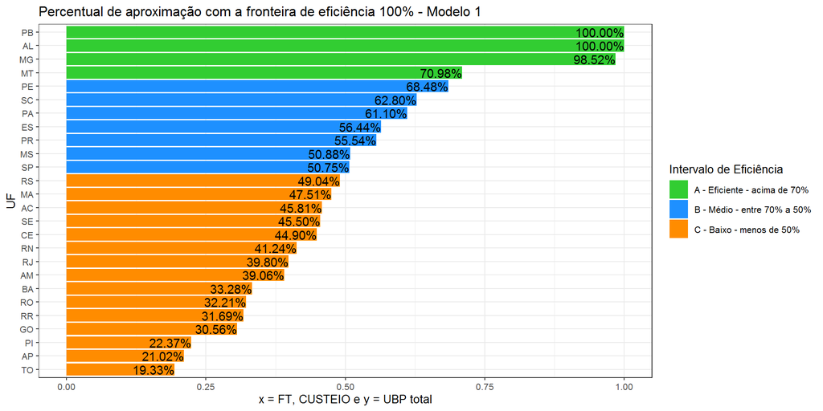

### 3.1.4 Mapa Brasil de aproximação com a fronteira de eficiência 100% nos estados da RBMLQ-I

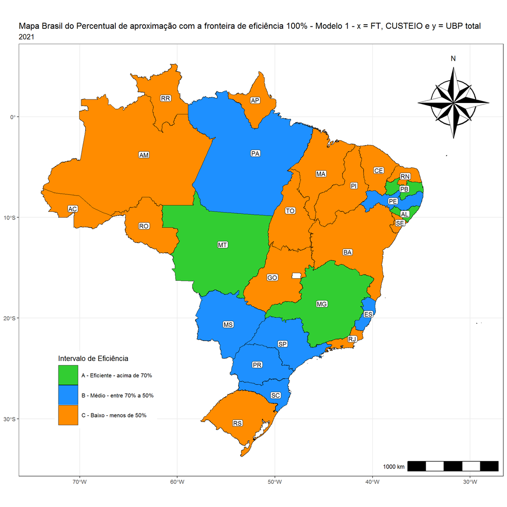

## 3.2 **Modelo 2**

### 3.2.1 Tabela de dados **Modelo 2** - **x = FT, CUSTEIO e y = Ubp_1000_hab**

Tabela de dados do Modelo 2

x = FT, CUSTEIO e y = Ubp_1000_hab

| uf | zf_ftp | zf_custeio_t | zy_ubp_1000_hab |
| --- | --- | --- | --- |
| AC | 0.0000 | 0.4746 | 1.4813 |
| AL | 8.4109 | 1.6083 | 9.4578 |
| AM | 7.4505 | 4.7446 | 7.7310 |
| AP | 0.1164 | 0.4693 | 0.0000 |
| BA | 34.1094 | 12.5812 | 23.3299 |
| CE | 19.7905 | 10.0357 | 12.0467 |
| ES | 4.7730 | 7.2210 | 8.7838 |
| GO | 15.7159 | 4.5840 | 6.7567 |
| MA | 7.2759 | 4.2341 | 7.4048 |
| MG | 21.3038 | 20.6580 | 47.1933 |
| MS | 6.4028 | 8.8980 | 9.3221 |
| MT | 9.8079 | 7.5533 | 18.1429 |
| PA | 5.0058 | 3.2569 | 9.9726 |
| PB | 5.5879 | 2.0351 | 17.9712 |
| PE | 7.8871 | 8.8842 | 14.9574 |
| PI | 6.6647 | 3.2318 | 3.6196 |
| PR | 22.5844 | 20.4269 | 27.4771 |
| RJ | 42.3749 | 24.8804 | 34.3880 |
| RN | 7.4505 | 2.9318 | 4.1030 |
| RO | 3.2596 | 0.8197 | 3.6093 |
| RR | 1.5134 | 0.0000 | 0.8699 |
| RS | 12.2235 | 7.8429 | 15.9710 |
| SC | 19.2084 | 11.7627 | 27.1745 |
| SE | 6.1409 | 2.5723 | 6.4598 |
| SP | 100.0000 | 100.0000 | 100.0000 |
| TO | 6.0536 | 1.8821 | 2.6785 |

### 3.2.2 Sumário da Tabela de dados do **Modelo 2** - **x = FT, CUSTEIO e y = Ubp_1000_hab**

```
##       uf                zf_ftp        zf_custeio_t    zy_ubp_1000_hab
##  Length:26          Min.   :  0.00   Min.   :  0.00   Min.   :  0.00
##  Class :character   1st Qu.:  5.70   1st Qu.:  2.17   1st Qu.:  4.69
##  Mode  :character   Median :  7.45   Median :  4.66   Median :  9.39
##                     Mean   : 14.66   Mean   : 10.52   Mean   : 16.19
##                     3rd Qu.: 18.34   3rd Qu.:  9.75   3rd Qu.: 18.10
##                     Max.   :100.00   Max.   :100.00   Max.   :100.00
```

### 3.2.3 Gráfico de barra

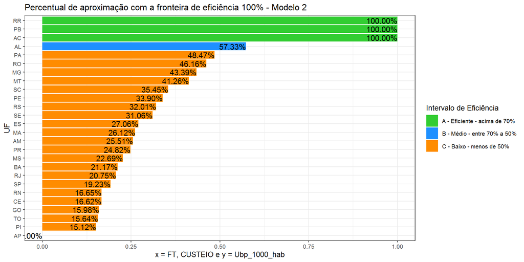

### 3.2.4 Mapa Brasil de aproximação com a fronteira de eficiência 100% nos estados da RBMLQ-I

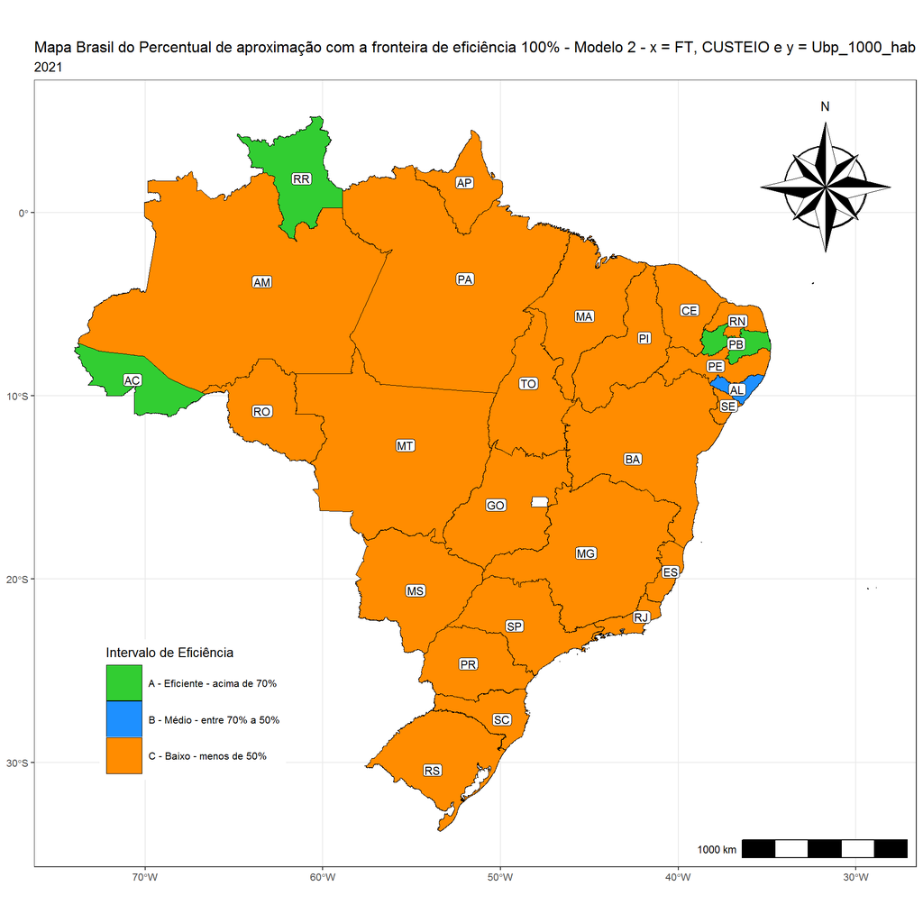

## 3.3 **Modelo 3**

### 3.3.1 Tabela de dados **Modelo 3** - **x = FT, CUSTEIO, INFRA e y = Ubp_1000_hab**

Tabela de dados do Modelo 3

x = FT, CUSTEIO, INFRA e y = Ubp_1000_hab

| uf | zf_ftp | zf_custeio_t | zs_infra | zy_ubp_1000_hab |
| --- | --- | --- | --- | --- |
| AC | 0.0000 | 0.4746 | 20.24 | 1.4813 |
| AL | 8.4109 | 1.6083 | 45.62 | 9.4578 |
| AM | 7.4505 | 4.7446 | 28.97 | 7.7310 |
| AP | 0.1164 | 0.4693 | 26.11 | 0.0000 |
| BA | 34.1094 | 12.5812 | 41.78 | 23.3299 |
| CE | 19.7905 | 10.0357 | 41.26 | 12.0467 |
| ES | 4.7730 | 7.2210 | 63.51 | 8.7838 |
| GO | 15.7159 | 4.5840 | 45.76 | 6.7567 |
| MA | 7.2759 | 4.2341 | 27.73 | 7.4048 |
| MG | 21.3038 | 20.6580 | 54.32 | 47.1933 |
| MS | 6.4028 | 8.8980 | 51.36 | 9.3221 |
| MT | 9.8079 | 7.5533 | 47.44 | 18.1429 |
| PA | 5.0058 | 3.2569 | 37.41 | 9.9726 |
| PB | 5.5879 | 2.0351 | 41.37 | 17.9712 |
| PE | 7.8871 | 8.8842 | 41.91 | 14.9574 |
| PI | 6.6647 | 3.2318 | 32.52 | 3.6196 |
| PR | 22.5844 | 20.4269 | 60.93 | 27.4771 |
| RJ | 42.3749 | 24.8804 | 82.79 | 34.3880 |
| RN | 7.4505 | 2.9318 | 44.92 | 4.1030 |
| RO | 3.2596 | 0.8197 | 31.52 | 3.6093 |
| RR | 1.5134 | 0.0000 | 20.67 | 0.8699 |
| RS | 12.2235 | 7.8429 | 55.69 | 15.9710 |
| SC | 19.2084 | 11.7627 | 65.20 | 27.1745 |
| SE | 6.1409 | 2.5723 | 49.40 | 6.4598 |
| SP | 100.0000 | 100.0000 | 61.38 | 100.0000 |
| TO | 6.0536 | 1.8821 | 36.60 | 2.6785 |

### 3.3.2 Sumário da Tabela de dados do **Modelo 3** - **x = FT, CUSTEIO, INFRA e y = Ubp_1000_hab**

```
##       uf                zf_ftp        zf_custeio_t       zs_infra
##  Length:26          Min.   :  0.00   Min.   :  0.00   Min.   :20.2
##  Class :character   1st Qu.:  5.70   1st Qu.:  2.17   1st Qu.:33.5
##  Mode  :character   Median :  7.45   Median :  4.66   Median :43.4
##                     Mean   : 14.66   Mean   : 10.52   Mean   :44.5
##                     3rd Qu.: 18.34   3rd Qu.:  9.75   3rd Qu.:53.6
##                     Max.   :100.00   Max.   :100.00   Max.   :82.8
##  zy_ubp_1000_hab
##  Min.   :  0.00
##  1st Qu.:  4.69
##  Median :  9.39
##  Mean   : 16.19
##  3rd Qu.: 18.10
##  Max.   :100.00
```

### 3.3.3 Gráfico de barra

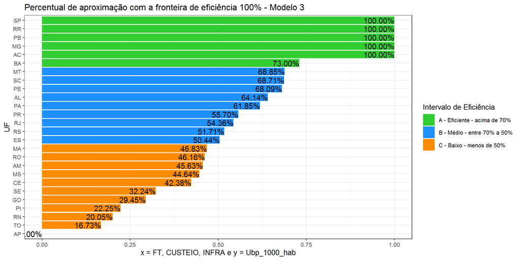

### 3.3.4 Mapa Brasil de aproximação com a fronteira de eficiência 100% nos estados da RBMLQ-I

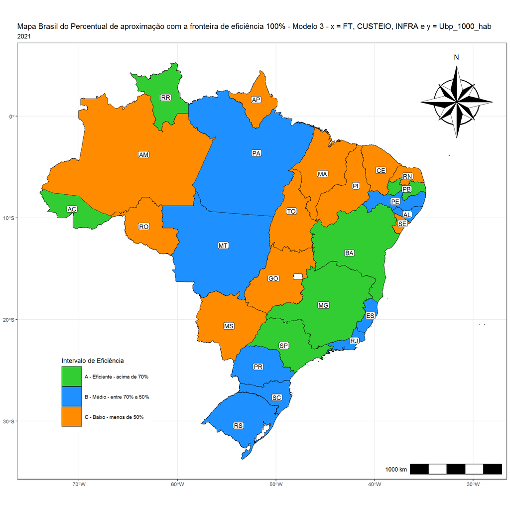

## 3.4 **Modelo 4**

### 3.4.1 Tabela de dados **Modelo 4** - **x = FT, CUSTEIO, INFRA e y = Ubp_1000_hab, REC_gerad**

Tabela de dados do Modelo 4

x = FT, CUSTEIO, INFRA e y = Ubp_1000_hab, REC_gerad

| uf | zf_ftp | zf_custeio_t | zs_infra | zy_ubp_1000_hab | rec_gerad_2021 |
| --- | --- | --- | --- | --- | --- |
| AC | 0.0000 | 0.4746 | 20.24 | 1.4813 | 0.1650 |
| AL | 8.4109 | 1.6083 | 45.62 | 9.4578 | 2.4503 |
| AM | 7.4505 | 4.7446 | 28.97 | 7.7310 | 5.0086 |
| AP | 0.1164 | 0.4693 | 26.11 | 0.0000 | 0.0000 |
| BA | 34.1094 | 12.5812 | 41.78 | 23.3299 | 15.1746 |
| CE | 19.7905 | 10.0357 | 41.26 | 12.0467 | 11.0371 |
| ES | 4.7730 | 7.2210 | 63.51 | 8.7838 | 7.0911 |
| GO | 15.7159 | 4.5840 | 45.76 | 6.7567 | 6.3966 |
| MA | 7.2759 | 4.2341 | 27.73 | 7.4048 | 5.1024 |
| MG | 21.3038 | 20.6580 | 54.32 | 47.1933 | 31.8963 |
| MS | 6.4028 | 8.8980 | 51.36 | 9.3221 | 8.2386 |
| MT | 9.8079 | 7.5533 | 47.44 | 18.1429 | 12.4704 |
| PA | 5.0058 | 3.2569 | 37.41 | 9.9726 | 7.4753 |
| PB | 5.5879 | 2.0351 | 41.37 | 17.9712 | 4.7456 |
| PE | 7.8871 | 8.8842 | 41.91 | 14.9574 | 11.6211 |
| PI | 6.6647 | 3.2318 | 32.52 | 3.6196 | 3.6728 |
| PR | 22.5844 | 20.4269 | 60.93 | 27.4771 | 24.8506 |
| RJ | 42.3749 | 24.8804 | 82.79 | 34.3880 | 29.5179 |
| RN | 7.4505 | 2.9318 | 44.92 | 4.1030 | 3.0067 |
| RO | 3.2596 | 0.8197 | 31.52 | 3.6093 | 3.2120 |
| RR | 1.5134 | 0.0000 | 20.67 | 0.8699 | 0.1189 |
| RS | 12.2235 | 7.8429 | 55.69 | 15.9710 | 18.0689 |
| SC | 19.2084 | 11.7627 | 65.20 | 27.1745 | 17.7818 |
| SE | 6.1409 | 2.5723 | 49.40 | 6.4598 | 2.2165 |
| SP | 100.0000 | 100.0000 | 61.38 | 100.0000 | 100.0000 |
| TO | 6.0536 | 1.8821 | 36.60 | 2.6785 | 1.6498 |

### 3.4.2 Sumário da Tabela de dados do **Modelo 4** - **x = FT, CUSTEIO, INFRA e y = Ubp_1000_hab, REC_gerad**

```
##       uf                zf_ftp        zf_custeio_t       zs_infra
##  Length:26          Min.   :  0.00   Min.   :  0.00   Min.   :20.2
##  Class :character   1st Qu.:  5.70   1st Qu.:  2.17   1st Qu.:33.5
##  Mode  :character   Median :  7.45   Median :  4.66   Median :43.4
##                     Mean   : 14.66   Mean   : 10.52   Mean   :44.5
##                     3rd Qu.: 18.34   3rd Qu.:  9.75   3rd Qu.:53.6
##                     Max.   :100.00   Max.   :100.00   Max.   :82.8
##  zy_ubp_1000_hab  rec_gerad_2021
##  Min.   :  0.00   Min.   :  0.00
##  1st Qu.:  4.69   1st Qu.:  3.06
##  Median :  9.39   Median :  6.74
##  Mean   : 16.19   Mean   : 12.81
##  3rd Qu.: 18.10   3rd Qu.: 14.50
##  Max.   :100.00   Max.   :100.00
```

### 3.4.3 Gráfico de barra

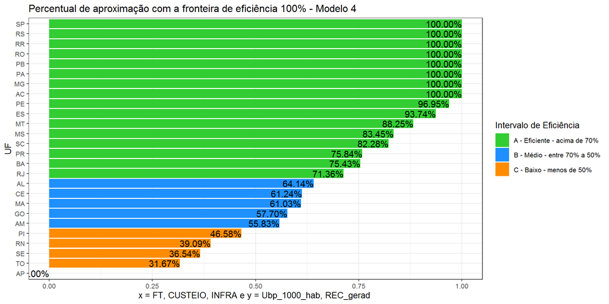

### 3.4.4 Mapa Brasil de aproximação com a fronteira de eficiência 100% nos estados da RBMLQ-I

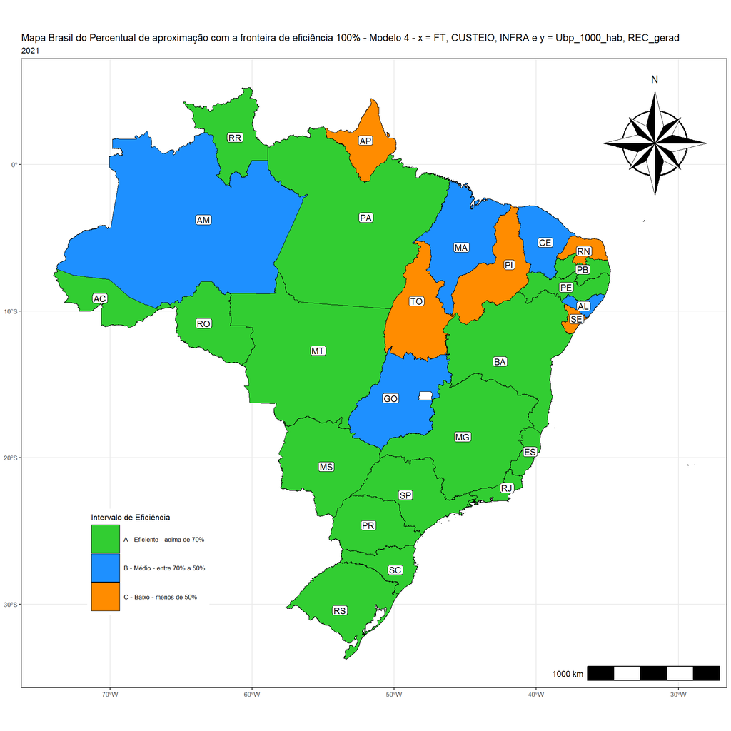

## 3.5 **Modelo 5**

### 3.5.1 Tabela de dados **Modelo 5** - **x = FT, CUSTEIO, INFRA e y = Ubp_1000_hab, REC_gerad, CUSTO_UBP**

Tabela de dados do Modelo 5

x = FT, CUSTEIO, INFRA e y = Ubp_1000_hab, REC_gerad, CUSTO_UBP

| uf | zf_ftp | zf_custeio_t | zs_infra | zy_ubp_1000_hab | rec_gerad_2021 | zy_custo_ubp_n |
| --- | --- | --- | --- | --- | --- | --- |
| AC | 0.0000 | 0.4746 | 20.24 | 1.4813 | 0.1650 | 82.05 |
| AL | 8.4109 | 1.6083 | 45.62 | 9.4578 | 2.4503 | 91.79 |
| AM | 7.4505 | 4.7446 | 28.97 | 7.7310 | 5.0086 | 48.37 |
| AP | 0.1164 | 0.4693 | 26.11 | 0.0000 | 0.0000 | 44.09 |
| BA | 34.1094 | 12.5812 | 41.78 | 23.3299 | 15.1746 | 52.38 |
| CE | 19.7905 | 10.0357 | 41.26 | 12.0467 | 11.0371 | 23.88 |
| ES | 4.7730 | 7.2210 | 63.51 | 8.7838 | 7.0911 | 27.02 |
| GO | 15.7159 | 4.5840 | 45.76 | 6.7567 | 6.3966 | 42.92 |
| MA | 7.2759 | 4.2341 | 27.73 | 7.4048 | 5.1024 | 52.69 |
| MG | 21.3038 | 20.6580 | 54.32 | 47.1933 | 31.8963 | 62.56 |
| MS | 6.4028 | 8.8980 | 51.36 | 9.3221 | 8.2386 | 13.36 |
| MT | 9.8079 | 7.5533 | 47.44 | 18.1429 | 12.4704 | 65.84 |
| PA | 5.0058 | 3.2569 | 37.41 | 9.9726 | 7.4753 | 76.03 |
| PB | 5.5879 | 2.0351 | 41.37 | 17.9712 | 4.7456 | 97.79 |
| PE | 7.8871 | 8.8842 | 41.91 | 14.9574 | 11.6211 | 47.65 |
| PI | 6.6647 | 3.2318 | 32.52 | 3.6196 | 3.6728 | 29.84 |
| PR | 22.5844 | 20.4269 | 60.93 | 27.4771 | 24.8506 | 30.16 |
| RJ | 42.3749 | 24.8804 | 82.79 | 34.3880 | 29.5179 | 31.83 |
| RN | 7.4505 | 2.9318 | 44.92 | 4.1030 | 3.0067 | 43.79 |
| RO | 3.2596 | 0.8197 | 31.52 | 3.6093 | 3.2120 | 86.86 |
| RR | 1.5134 | 0.0000 | 20.67 | 0.8699 | 0.1189 | 100.00 |
| RS | 12.2235 | 7.8429 | 55.69 | 15.9710 | 18.0689 | 58.22 |
| SC | 19.2084 | 11.7627 | 65.20 | 27.1745 | 17.7818 | 63.56 |
| SE | 6.1409 | 2.5723 | 49.40 | 6.4598 | 2.2165 | 69.99 |
| SP | 100.0000 | 100.0000 | 61.38 | 100.0000 | 100.0000 | 0.00 |
| TO | 6.0536 | 1.8821 | 36.60 | 2.6785 | 1.6498 | 49.58 |

### 3.5.2 Sumário da Tabela de dados do **Modelo 5** - **x = FT, CUSTEIO, INFRA e y = Ubp_1000_hab, REC_gerad, CUSTO_UBP**

```
##       uf                zf_ftp        zf_custeio_t       zs_infra
##  Length:26          Min.   :  0.00   Min.   :  0.00   Min.   :20.2
##  Class :character   1st Qu.:  5.70   1st Qu.:  2.17   1st Qu.:33.5
##  Mode  :character   Median :  7.45   Median :  4.66   Median :43.4
##                     Mean   : 14.66   Mean   : 10.52   Mean   :44.5
##                     3rd Qu.: 18.34   3rd Qu.:  9.75   3rd Qu.:53.6
##                     Max.   :100.00   Max.   :100.00   Max.   :82.8
##  zy_ubp_1000_hab  rec_gerad_2021   zy_custo_ubp_n
##  Min.   :  0.00   Min.   :  0.00   Min.   :  0.0
##  1st Qu.:  4.69   1st Qu.:  3.06   1st Qu.: 34.6
##  Median :  9.39   Median :  6.74   Median : 51.0
##  Mean   : 16.19   Mean   : 12.81   Mean   : 53.5
##  3rd Qu.: 18.10   3rd Qu.: 14.50   3rd Qu.: 69.0
##  Max.   :100.00   Max.   :100.00   Max.   :100.0
```

### 3.5.3 Gráfico de barra

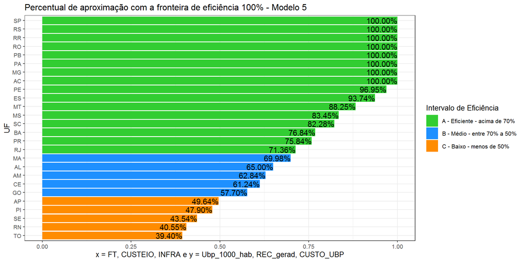

### 3.5.4 Mapa Brasil de aproximação com a fronteira de eficiência 100% nos estados da RBMLQ-I

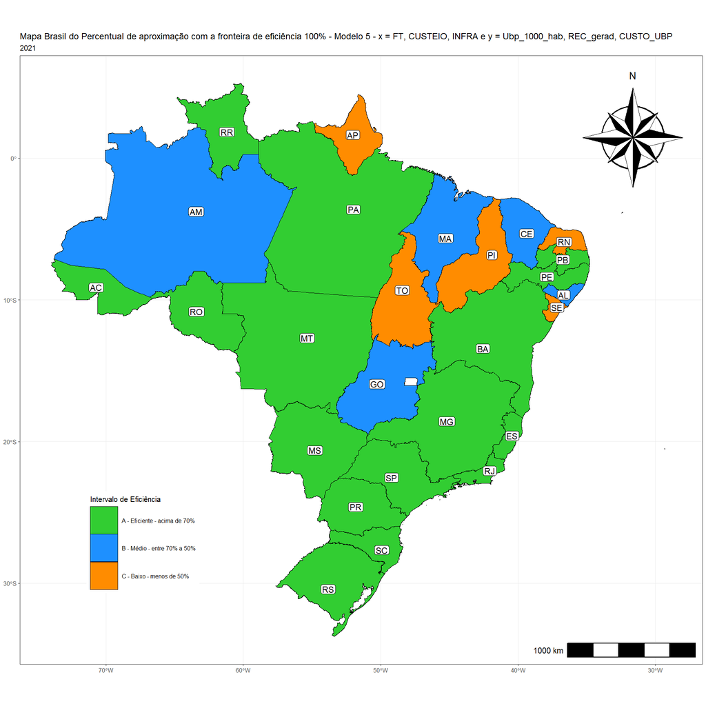

# 4 Diversos

## 4.2 Material de Apoio

- Tabela de Cores HTML (nome, hexadecimal e RGB):
- Tutorial - Data Envelopment Analysis with deaR:
- Tratamento de Outliers (Bacon) - R na Pesquisa Contábil: [Alessanderson Jacó de Carvalho](https://youtu.be/hfO5LLbRioY)
- PLAYLIST - R na Pesquisa Contábil (Parte 1 ao 20):
- Utilização da metodologia DEA (Data Envelopment Analysis) para avaliar o impacto das TIC sobre a produtividade na indústria da hospitalidade:
- PLAYLIST - Criando gráficos no R com o ggplot2 (Parte 1 ao 2): [Fernanda Peres](https://youtu.be/DYsPRa3vpf0)
- PLAYLIST - R Markdown: Gerando relatórios usando o R (Parte 1 ao 5): [Fernanda Peres](https://youtu.be/obxa5VH4WvY)
- Minicurso R - UFPR: [UFPR](https://youtu.be/obxa5VH4WvY)
- R Markdown: The Definitive Guide: [Yihui Xie, J. J. Allaire, Garrett Grolemund](https://bookdown.org/yihui/rmarkdown/)